# Bike Sharing System Data Exploration

## Preliminary Wrangling

> This data set includes information about individual rides made in a bike-sharing system covering the greater San Francisco Bay area.

```python
# import all packages and set plots to be embedded inline
from datetime import datetime
import numpy as np
import pandas as pd
import matplotlib.pyplot as plt
import seaborn as sb

%matplotlib inline
```

```python
# load in the dataset into a pandas dataframe
bike_shares_df = pd.read_csv('fordgobike-tripdata.csv')
```

```python
# explore data
bike_shares_df.shape
```

```
(183412, 16)
```

```python
bike_shares_df.info()
```

```
<class 'pandas.core.frame.DataFrame'>
RangeIndex: 183412 entries, 0 to 183411
Data columns (total 16 columns):
 #   Column                   Non-Null Count   Dtype
---  ------                   --------------   -----
 0   duration_sec             183412 non-null  int64
 1   start_time               183412 non-null  object
 2   end_time                 183412 non-null  object
 3   start_station_id         183215 non-null  float64
 4   start_station_name       183215 non-null  object
 5   start_station_latitude   183412 non-null  float64
 6   start_station_longitude  183412 non-null  float64
 7   end_station_id           183215 non-null  float64
 8   end_station_name         183215 non-null  object
 9   end_station_latitude     183412 non-null  float64
 10  end_station_longitude    183412 non-null  float64
 11  bike_id                  183412 non-null  int64
 12  user_type                183412 non-null  object
 13  member_birth_year        175147 non-null  float64
 14  member_gender            175147 non-null  object
 15  bike_share_for_all_trip  183412 non-null  object
dtypes: float64(7), int64(2), object(7)
memory usage: 22.4+ MB
```

```python
bike_shares_df.head(5)
```

|  | duration_sec | start_time | end_time | start_station_id | start_station_name | start_station_latitude | start_station_longitude | end_station_id | end_station_name | end_station_latitude | end_station_longitude | bike_id | user_type | member_birth_year | member_gender | bike_share_for_all_trip |
| --- | --- | --- | --- | --- | --- | --- | --- | --- | --- | --- | --- | --- | --- | --- | --- | --- |
| 0 | 52185 | 2019-02-28 17:32:10.1450 | 2019-03-01 08:01:55.9750 | 21.0 | Montgomery St BART Station (Market St at 2nd St) | 37.789625 | -122.400811 | 13.0 | Commercial St at Montgomery St | 37.794231 | -122.402923 | 4902 | Customer | 1984.0 | Male | No |
| 1 | 42521 | 2019-02-28 18:53:21.7890 | 2019-03-01 06:42:03.0560 | 23.0 | The Embarcadero at Steuart St | 37.791464 | -122.391034 | 81.0 | Berry St at 4th St | 37.775880 | -122.393170 | 2535 | Customer | NaN | NaN | No |
| 2 | 61854 | 2019-02-28 12:13:13.2180 | 2019-03-01 05:24:08.1460 | 86.0 | Market St at Dolores St | 37.769305 | -122.426826 | 3.0 | Powell St BART Station (Market St at 4th St) | 37.786375 | -122.404904 | 5905 | Customer | 1972.0 | Male | No |
| 3 | 36490 | 2019-02-28 17:54:26.0100 | 2019-03-01 04:02:36.8420 | 375.0 | Grove St at Masonic Ave | 37.774836 | -122.446546 | 70.0 | Central Ave at Fell St | 37.773311 | -122.444293 | 6638 | Subscriber | 1989.0 | Other | No |
| 4 | 1585 | 2019-02-28 23:54:18.5490 | 2019-03-01 00:20:44.0740 | 7.0 | Frank H Ogawa Plaza | 37.804562 | -122.271738 | 222.0 | 10th Ave at E 15th St | 37.792714 | -122.248780 | 4898 | Subscriber | 1974.0 | Male | Yes |

#### We need to do some data wrangling to convert data types into more appropriate types

1) Convert `start_station_id`, `end_station_id` and `member_birth_year` columns to `int` instead of float

2) Convert `duration_sec` to `minutes` instead of seconds to be more readable and rename column to `duration_min`

3) Convert `start_time`, `end_time` to `datetime` type

4) Convert `user_type`, `member_gender` to `category` type

5) Convert `bike_share_for_all_trip` to `boolean` type

6) Create `day_of_week` column using `start_time` to use in the data analysis

7) Create `age` column using `member_birth_year` & remove `member_birth_year` column

8) Create `hour_of_day` column using `start_time` to use in the data analysis

```python
# check first for nan

print(bike_shares_df.start_station_id.isna().sum())

print(bike_shares_df.end_station_id.isna().sum())

print(bike_shares_df.member_birth_year.isna().sum())
```

```
197
197
8265
```

```python
# remove nan values

bike_shares_df = bike_shares_df.dropna()
```

```python
# check again

bike_shares_df.info() # nan values have been removed
```

```
<class 'pandas.core.frame.DataFrame'>
Int64Index: 174952 entries, 0 to 183411
Data columns (total 16 columns):
 #   Column                   Non-Null Count   Dtype
---  ------                   --------------   -----
 0   duration_sec             174952 non-null  int64
 1   start_time               174952 non-null  object
 2   end_time                 174952 non-null  object
 3   start_station_id         174952 non-null  float64
 4   start_station_name       174952 non-null  object
 5   start_station_latitude   174952 non-null  float64
 6   start_station_longitude  174952 non-null  float64
 7   end_station_id           174952 non-null  float64
 8   end_station_name         174952 non-null  object
 9   end_station_latitude     174952 non-null  float64
 10  end_station_longitude    174952 non-null  float64
 11  bike_id                  174952 non-null  int64
 12  user_type                174952 non-null  object
 13  member_birth_year        174952 non-null  float64
 14  member_gender            174952 non-null  object
 15  bike_share_for_all_trip  174952 non-null  object
dtypes: float64(7), int64(2), object(7)
memory usage: 22.7+ MB
```

```python
# convert start_station_id, end_station_id, member_birth_year types to int

bike_shares_df = bike_shares_df.astype({
    "start_station_id": 'int', "end_station_id": 'int', "member_birth_year": 'int'
})
```

```python
# check again

bike_shares_df.info() # column types has chagned to int
```

```
<class 'pandas.core.frame.DataFrame'>
Int64Index: 174952 entries, 0 to 183411
Data columns (total 16 columns):
 #   Column                   Non-Null Count   Dtype
---  ------                   --------------   -----
 0   duration_sec             174952 non-null  int64
 1   start_time               174952 non-null  object
 2   end_time                 174952 non-null  object
 3   start_station_id         174952 non-null  int64
 4   start_station_name       174952 non-null  object
 5   start_station_latitude   174952 non-null  float64
 6   start_station_longitude  174952 non-null  float64
 7   end_station_id           174952 non-null  int64
 8   end_station_name         174952 non-null  object
 9   end_station_latitude     174952 non-null  float64
 10  end_station_longitude    174952 non-null  float64
 11  bike_id                  174952 non-null  int64
 12  user_type                174952 non-null  object
 13  member_birth_year        174952 non-null  int64
 14  member_gender            174952 non-null  object
 15  bike_share_for_all_trip  174952 non-null  object
dtypes: float64(4), int64(5), object(7)
memory usage: 22.7+ MB
```

```python
# change duration_sec to minutes

bike_shares_df.duration_sec = (bike_shares_df.duration_sec / 60).map(lambda x: '%2.1f' % x).astype('float')
```

```python
# rename duration_sec column

bike_shares_df.rename(columns={"duration_sec": 'duration_min'}, inplace=True);
```

```python
# check again

bike_shares_df.info() # column types has chagned to int
```

```
<class 'pandas.core.frame.DataFrame'>
Int64Index: 174952 entries, 0 to 183411
Data columns (total 16 columns):
 #   Column                   Non-Null Count   Dtype
---  ------                   --------------   -----
 0   duration_min             174952 non-null  float64
 1   start_time               174952 non-null  object
 2   end_time                 174952 non-null  object
 3   start_station_id         174952 non-null  int64
 4   start_station_name       174952 non-null  object
 5   start_station_latitude   174952 non-null  float64
 6   start_station_longitude  174952 non-null  float64
 7   end_station_id           174952 non-null  int64
 8   end_station_name         174952 non-null  object
 9   end_station_latitude     174952 non-null  float64
 10  end_station_longitude    174952 non-null  float64
 11  bike_id                  174952 non-null  int64
 12  user_type                174952 non-null  object
 13  member_birth_year        174952 non-null  int64
 14  member_gender            174952 non-null  object
 15  bike_share_for_all_trip  174952 non-null  object
dtypes: float64(5), int64(4), object(7)
memory usage: 22.7+ MB
```

```python
# change start_time, end_time columns to datetime

bike_shares_df.start_time = pd.to_datetime(bike_shares_df.start_time)

bike_shares_df.end_time = pd.to_datetime(bike_shares_df.end_time)
```

```python
# check again

bike_shares_df.info() # column types has chagned to datetime
```

```
<class 'pandas.core.frame.DataFrame'>
Int64Index: 174952 entries, 0 to 183411
Data columns (total 16 columns):
 #   Column                   Non-Null Count   Dtype
---  ------                   --------------   -----
 0   duration_min             174952 non-null  float64
 1   start_time               174952 non-null  datetime64[ns]
 2   end_time                 174952 non-null  datetime64[ns]
 3   start_station_id         174952 non-null  int64
 4   start_station_name       174952 non-null  object
 5   start_station_latitude   174952 non-null  float64
 6   start_station_longitude  174952 non-null  float64
 7   end_station_id           174952 non-null  int64
 8   end_station_name         174952 non-null  object
 9   end_station_latitude     174952 non-null  float64
 10  end_station_longitude    174952 non-null  float64
 11  bike_id                  174952 non-null  int64
 12  user_type                174952 non-null  object
 13  member_birth_year        174952 non-null  int64
 14  member_gender            174952 non-null  object
 15  bike_share_for_all_trip  174952 non-null  object
dtypes: datetime64[ns](2), float64(5), int64(4), object(5)
memory usage: 22.7+ MB
```

```python
# convert user_type, member_gender to category type

bike_shares_df = bike_shares_df.astype({"user_type": 'category', "member_gender":'category'})
```

```python
# check again

bike_shares_df.info() # column types has chagned to category
```

```
<class 'pandas.core.frame.DataFrame'>
Int64Index: 174952 entries, 0 to 183411
Data columns (total 16 columns):
 #   Column                   Non-Null Count   Dtype
---  ------                   --------------   -----
 0   duration_min             174952 non-null  float64
 1   start_time               174952 non-null  datetime64[ns]
 2   end_time                 174952 non-null  datetime64[ns]
 3   start_station_id         174952 non-null  int64
 4   start_station_name       174952 non-null  object
 5   start_station_latitude   174952 non-null  float64
 6   start_station_longitude  174952 non-null  float64
 7   end_station_id           174952 non-null  int64
 8   end_station_name         174952 non-null  object
 9   end_station_latitude     174952 non-null  float64
 10  end_station_longitude    174952 non-null  float64
 11  bike_id                  174952 non-null  int64
 12  user_type                174952 non-null  category
 13  member_birth_year        174952 non-null  int64
 14  member_gender            174952 non-null  category
 15  bike_share_for_all_trip  174952 non-null  object
dtypes: category(2), datetime64[ns](2), float64(5), int64(4), object(3)
memory usage: 20.4+ MB
```

```python
# show bike_share_for_all_trip values

print(bike_shares_df.bike_share_for_all_trip.value_counts())

# map values to True, False

bike_shares_df = bike_shares_df.replace({'bike_share_for_all_trip': {'Yes': True, 'No': False}})

# convert bike_share_for_all_trip to boolean type

bike_shares_df.bike_share_for_all_trip = bike_shares_df.bike_share_for_all_trip.astype('bool')
```

```
No     157606
Yes     17346
Name: bike_share_for_all_trip, dtype: int64
```

```python
# check again

bike_shares_df.info() # column type changed to bool
```

```
<class 'pandas.core.frame.DataFrame'>
Int64Index: 174952 entries, 0 to 183411
Data columns (total 16 columns):
 #   Column                   Non-Null Count   Dtype
---  ------                   --------------   -----
 0   duration_min             174952 non-null  float64
 1   start_time               174952 non-null  datetime64[ns]
 2   end_time                 174952 non-null  datetime64[ns]
 3   start_station_id         174952 non-null  int64
 4   start_station_name       174952 non-null  object
 5   start_station_latitude   174952 non-null  float64
 6   start_station_longitude  174952 non-null  float64
 7   end_station_id           174952 non-null  int64
 8   end_station_name         174952 non-null  object
 9   end_station_latitude     174952 non-null  float64
 10  end_station_longitude    174952 non-null  float64
 11  bike_id                  174952 non-null  int64
 12  user_type                174952 non-null  category
 13  member_birth_year        174952 non-null  int64
 14  member_gender            174952 non-null  category
 15  bike_share_for_all_trip  174952 non-null  bool
dtypes: bool(1), category(2), datetime64[ns](2), float64(5), int64(4), object(2)
memory usage: 19.2+ MB
```

```python
# create day_of_week column using start_time

bike_shares_df['start_day_of_week'] = bike_shares_df.start_time.dt.day_name().astype('category')
```

```python
# check data

bike_shares_df.info()
```

```
<class 'pandas.core.frame.DataFrame'>
Int64Index: 174952 entries, 0 to 183411
Data columns (total 17 columns):
 #   Column                   Non-Null Count   Dtype
---  ------                   --------------   -----
 0   duration_min             174952 non-null  float64
 1   start_time               174952 non-null  datetime64[ns]
 2   end_time                 174952 non-null  datetime64[ns]
 3   start_station_id         174952 non-null  int64
 4   start_station_name       174952 non-null  object
 5   start_station_latitude   174952 non-null  float64
 6   start_station_longitude  174952 non-null  float64
 7   end_station_id           174952 non-null  int64
 8   end_station_name         174952 non-null  object
 9   end_station_latitude     174952 non-null  float64
 10  end_station_longitude    174952 non-null  float64
 11  bike_id                  174952 non-null  int64
 12  user_type                174952 non-null  category
 13  member_birth_year        174952 non-null  int64
 14  member_gender            174952 non-null  category
 15  bike_share_for_all_trip  174952 non-null  bool
 16  start_day_of_week        174952 non-null  category
dtypes: bool(1), category(3), datetime64[ns](2), float64(5), int64(4), object(2)
memory usage: 19.4+ MB
```

```python
# create hour_of_day column

bike_shares_df['start_hour_of_day'] = bike_shares_df.start_time.dt.hour
```

```python
# check data

bike_shares_df.info()
```

```
<class 'pandas.core.frame.DataFrame'>
Int64Index: 174952 entries, 0 to 183411
Data columns (total 18 columns):
 #   Column                   Non-Null Count   Dtype
---  ------                   --------------   -----
 0   duration_min             174952 non-null  float64
 1   start_time               174952 non-null  datetime64[ns]
 2   end_time                 174952 non-null  datetime64[ns]
 3   start_station_id         174952 non-null  int64
 4   start_station_name       174952 non-null  object
 5   start_station_latitude   174952 non-null  float64
 6   start_station_longitude  174952 non-null  float64
 7   end_station_id           174952 non-null  int64
 8   end_station_name         174952 non-null  object
 9   end_station_latitude     174952 non-null  float64
 10  end_station_longitude    174952 non-null  float64
 11  bike_id                  174952 non-null  int64
 12  user_type                174952 non-null  category
 13  member_birth_year        174952 non-null  int64
 14  member_gender            174952 non-null  category
 15  bike_share_for_all_trip  174952 non-null  bool
 16  start_day_of_week        174952 non-null  category
 17  start_hour_of_day        174952 non-null  int64
dtypes: bool(1), category(3), datetime64[ns](2), float64(5), int64(5), object(2)
memory usage: 20.7+ MB
```

```python
# create age column

bike_shares_df['age'] = bike_shares_df.member_birth_year.apply(lambda x: datetime.today().year - x)


# remove birth year column

bike_shares_df.drop('member_birth_year', axis=1, inplace=True)
```

```python
# check data

bike_shares_df.info()
```

```
<class 'pandas.core.frame.DataFrame'>
Int64Index: 174952 entries, 0 to 183411
Data columns (total 18 columns):
 #   Column                   Non-Null Count   Dtype
---  ------                   --------------   -----
 0   duration_min             174952 non-null  float64
 1   start_time               174952 non-null  datetime64[ns]
 2   end_time                 174952 non-null  datetime64[ns]
 3   start_station_id         174952 non-null  int64
 4   start_station_name       174952 non-null  object
 5   start_station_latitude   174952 non-null  float64
 6   start_station_longitude  174952 non-null  float64
 7   end_station_id           174952 non-null  int64
 8   end_station_name         174952 non-null  object
 9   end_station_latitude     174952 non-null  float64
 10  end_station_longitude    174952 non-null  float64
 11  bike_id                  174952 non-null  int64
 12  user_type                174952 non-null  category
 13  member_gender            174952 non-null  category
 14  bike_share_for_all_trip  174952 non-null  bool
 15  start_day_of_week        174952 non-null  category
 16  start_hour_of_day        174952 non-null  int64
 17  age                      174952 non-null  int64
dtypes: bool(1), category(3), datetime64[ns](2), float64(5), int64(5), object(2)
memory usage: 20.7+ MB
```

```python
bike_shares_df.head(5)
```

|  | duration_min | start_time | end_time | start_station_id | start_station_name | start_station_latitude | start_station_longitude | end_station_id | end_station_name | end_station_latitude | end_station_longitude | bike_id | user_type | member_gender | bike_share_for_all_trip | start_day_of_week | start_hour_of_day | age |
| --- | --- | --- | --- | --- | --- | --- | --- | --- | --- | --- | --- | --- | --- | --- | --- | --- | --- | --- |
| 0 | 869.8 | 2019-02-28 17:32:10.145 | 2019-03-01 08:01:55.975 | 21 | Montgomery St BART Station (Market St at 2nd St) | 37.789625 | -122.400811 | 13 | Commercial St at Montgomery St | 37.794231 | -122.402923 | 4902 | Customer | Male | False | Thursday | 17 | 37 |
| 2 | 1030.9 | 2019-02-28 12:13:13.218 | 2019-03-01 05:24:08.146 | 86 | Market St at Dolores St | 37.769305 | -122.426826 | 3 | Powell St BART Station (Market St at 4th St) | 37.786375 | -122.404904 | 5905 | Customer | Male | False | Thursday | 12 | 49 |
| 3 | 608.2 | 2019-02-28 17:54:26.010 | 2019-03-01 04:02:36.842 | 375 | Grove St at Masonic Ave | 37.774836 | -122.446546 | 70 | Central Ave at Fell St | 37.773311 | -122.444293 | 6638 | Subscriber | Other | False | Thursday | 17 | 32 |
| 4 | 26.4 | 2019-02-28 23:54:18.549 | 2019-03-01 00:20:44.074 | 7 | Frank H Ogawa Plaza | 37.804562 | -122.271738 | 222 | 10th Ave at E 15th St | 37.792714 | -122.248780 | 4898 | Subscriber | Male | True | Thursday | 23 | 47 |
| 5 | 29.9 | 2019-02-28 23:49:58.632 | 2019-03-01 00:19:51.760 | 93 | 4th St at Mission Bay Blvd S | 37.770407 | -122.391198 | 323 | Broadway at Kearny | 37.798014 | -122.405950 | 5200 | Subscriber | Male | False | Thursday | 23 | 62 |

### Expore the data

```python
# show some descriptive statistics for duration, age variables

bike_shares_df[['duration_min', 'age']].describe()
```

|  | duration_min | age |
| --- | --- | --- |
| count | 174952.000000 | 174952.000000 |
| mean | 11.733617 | 36.196865 |
| std | 27.370095 | 10.118731 |
| min | 1.000000 | 20.000000 |
| 25% | 5.400000 | 29.000000 |
| 50% | 8.500000 | 34.000000 |
| 75% | 13.200000 | 41.000000 |
| max | 1409.100000 | 143.000000 |

```python
# explore start stations names, counts

bike_shares_df.start_station_name.value_counts()
```

```
Market St at 10th St                                         3649
San Francisco Caltrain Station 2  (Townsend St at 4th St)    3408
Berry St at 4th St                                           2952
Montgomery St BART Station (Market St at 2nd St)             2711
Powell St BART Station (Market St at 4th St)                 2620
                                                             ...
Willow St at Vine St                                            9
Parker Ave at McAllister St                                     7
21st Ave at International Blvd                                  4
Palm St at Willow St                                            3
16th St Depot                                                   2
Name: start_station_name, Length: 329, dtype: int64
```

```python
# explore end stations names, counts

bike_shares_df.end_station_name.value_counts()
```

```
San Francisco Caltrain Station 2  (Townsend St at 4th St)    4624
Market St at 10th St                                         3709
Montgomery St BART Station (Market St at 2nd St)             3461
San Francisco Ferry Building (Harry Bridges Plaza)           3151
San Francisco Caltrain (Townsend St at 4th St)               2870
                                                             ...
Parker Ave at McAllister St                                     9
Palm St at Willow St                                            7
16th St Depot                                                   6
Willow St at Vine St                                            5
21st Ave at International Blvd                                  5
Name: end_station_name, Length: 329, dtype: int64
```

```python
# explore member_gender value counts

bike_shares_df.member_gender.value_counts()
```

```
Male      130500
Female     40805
Other       3647
Name: member_gender, dtype: int64
```

```python
# explore bike_share_for_all_trip value counts

bike_shares_df.bike_share_for_all_trip.value_counts()
```

```
False    157606
True      17346
Name: bike_share_for_all_trip, dtype: int64
```

```python
# explore member_birth_year value counts

bike_shares_df.age.value_counts()
```

```
33     10214
28      9323
32      8967
31      8640
30      8484
       ...
91         1
93         1
94         1
111        1
143        1
Name: age, Length: 75, dtype: int64
```

```python
# explore member_birth_year value counts

bike_shares_df.user_type.value_counts()
```

```
Subscriber    158386
Customer       16566
Name: user_type, dtype: int64
```

### What is the structure of your dataset?

There are 183,412 bike shares in the dataset with 16 features:

- some variables are date times like ('start_time', 'end_time')
- some are strings like ('start_station_name', 'end_station_name')
- some are floats representing coordinates like ('start_station_latitude', 'start_station_longitude', 'end_station_latitude', 'end_station_longitude')
- some are numeric represnting ids like ('start_station_id', 'end_station_id', 'bike_id')
- one is numeric representing trip duration in seconds 'duration_sec'
- one is numberic representing birth year of member 'member_birth_year'
- some are strings representing categories ('user_type', 'member_gender')
- one is string representing boolean value 'bike_share_for_all_trip'

### What is/are the main feature(s) of interest in your dataset?

> I'm interested in exploring dataset and answering some questions about the data & get some insights about how `day of week`, `hour of day`, `trip duration` and `customer type` affect other features.

#### Main Questions:

- When are most trips taken in terms of time of day or day of the week?
- How long does the average trip take?
- Does the above depend on if a user is a subscriber or customer?

### What features in the dataset do you think will help support your investigation into your feature(s) of interest?

- Some features I'll use to get new features of interest like `start_time` which I'll use to get day of week and hour of the day and also `member_birth_year` which I'll use to get member age.
- Some features I'll use to explore how features of interest interact with them like `age`, `gender`

## Univariate Exploration

### In this section we are interested to find answers for the following questions:

- When are most trips taken in terms of time of day or day of the week?
- How long does the average trip take?
- What is the average age of users?

### Also we want to take a look at distribution of the following columns:

- Age
- Gender
- User Type
- Day of week
- Hour of day
- Trip Duration

#### 1. When are most trips taken in terms of time of day or day of the week?

> Answer: Hour: **17**, Day: **Thursday**

```python
# get start_hour_of_day value counts

bike_shares_df.start_hour_of_day.value_counts()
```

```
17    20904
8     20227
18    16118
9     15204
16    13473
7     10231
19     9424
15     8646
12     8220
13     8098
10     7970
14     7677
11     7461
20     6211
21     4400
6      3293
22     2793
23     1572
0       893
5       866
1       525
2       355
4       227
3       164
Name: start_hour_of_day, dtype: int64
```

```python
# explore start_day_of_week value counts

bike_shares_df.start_day_of_week.value_counts()
```

```
Thursday     33712
Tuesday      30584
Wednesday    28426
Friday       27663
Monday       25641
Sunday       14512
Saturday     14414
Name: start_day_of_week, dtype: int64
```

#### 2. How long does average trip take ?

> Answer: **11.733617** minutes

```python
# get trip duration mean value

bike_shares_df.duration_min.mean()
```

```
11.733616649138048
```

#### 3. What is the average age of users?

> Answer: **36** years

```python
# get age mean value

bike_shares_df.age.mean()
```

```
36.196865425945404
```

#### 1. Age distribution

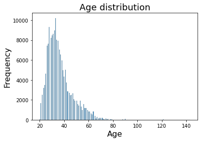

```python
# plot Age distribution
sb.histplot(bike_shares_df.age, kde = False)
plt.title('Age distribution', fontsize=18)
plt.xlabel('Age', fontsize=16)
plt.ylabel('Frequency', fontsize=16)
plt.show()
```

#### 2. Gender distribution

```python
# get gender value counts

gender_counts = bike_shares_df.member_gender.value_counts()
```

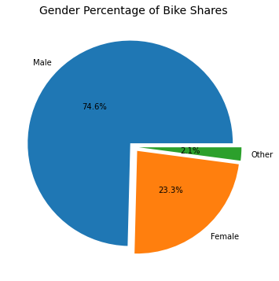

```python
# plot pie chart

pie, ax = plt.subplots(figsize=[10,6])
labels = gender_counts.keys()
plt.pie(x=gender_counts, autopct="%.1f%%", explode=[0.05]*3, labels=labels, pctdistance=0.5)
plt.title("Gender Percentage of Bike Shares", fontsize=14);
```

#### 3. User Type distribution

```python
# get gender value counts

user_types_counts = bike_shares_df.user_type.value_counts()
```

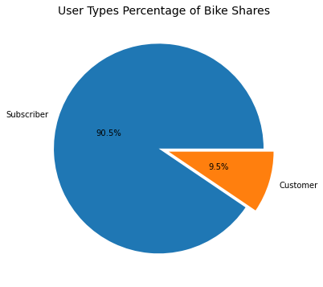

```python
# plot pie chart

pie, ax = plt.subplots(figsize=[10,6])
labels = user_types_counts.keys()
plt.pie(x=user_types_counts, autopct="%.1f%%", explode=[0.05]*2, labels=labels, pctdistance=0.5)
plt.title("User Types Percentage of Bike Shares", fontsize=14);
```

#### 4. Day of week, Hour of day distributions

```
[Text(0.5, 0, 'Hour of Day'), Text(0, 0.5, 'Frequency')]
```

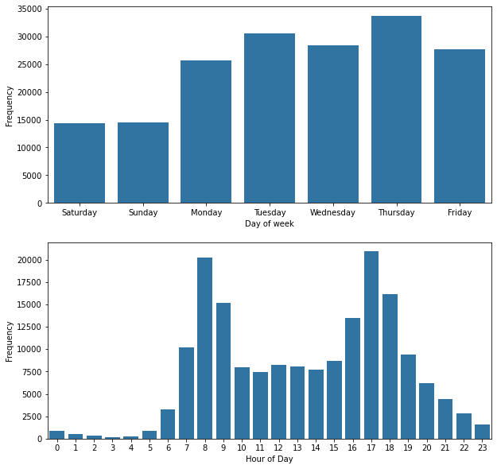

```python
# plot bar charts

fig, ax = plt.subplots(nrows=2, figsize = [10, 10])

default_color = sb.color_palette()[0]
sb.countplot(
    data = bike_shares_df,
    x = 'start_day_of_week',
    color = default_color,
    order=['Saturday', 'Sunday', 'Monday', 'Tuesday', 'Wednesday', 'Thursday', 'Friday'],
    ax = ax[0]).set(xlabel='Day of week', ylabel='Frequency')
sb.countplot(data = bike_shares_df, x = 'start_hour_of_day', color = default_color, ax = ax[1]).set(xlabel='Hour of Day', ylabel='Frequency')
```

#### 5. Trip Duration distribution

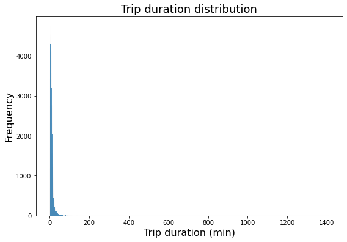

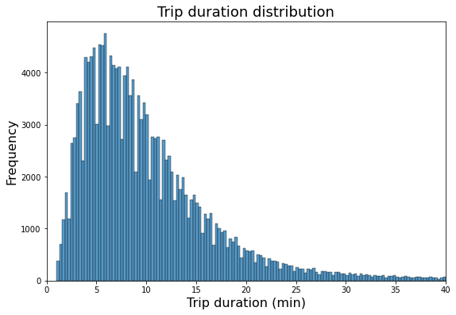

```python
# plot trip Duration distribution

plt.figure(figsize = [9, 6])

sb.histplot(bike_shares_df.duration_min, kde = False)
plt.title('Trip duration distribution', fontsize=18)
plt.xlabel('Trip duration (min)', fontsize=16)
plt.ylabel('Frequency', fontsize=16)
plt.show()

# limit x values to 40

plt.figure(figsize = [9, 6])

plt.xlim(0, 40)
sb.histplot(bike_shares_df.duration_min, kde = False)
plt.title('Trip duration distribution', fontsize=18)
plt.xlabel('Trip duration (min)', fontsize=16)
plt.ylabel('Frequency', fontsize=16)
plt.show()
```

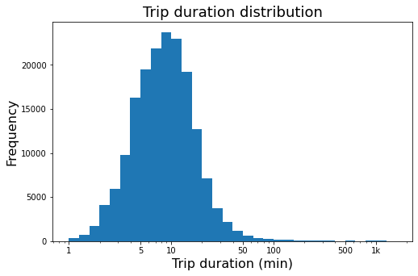

```python
# let's put it on a log scale because there's a long tail

log_binsize = 0.1

bins = 10 ** np.arange(0, np.log10(bike_shares_df['duration_min'].max()) + log_binsize, log_binsize)

plt.figure(figsize=[8, 5])
plt.hist(data = bike_shares_df, x = 'duration_min', bins = bins)
plt.xscale('log')
plt.xticks([1, 5, 10, 50, 100, 500, 1000], [1, 5, 10, 50, 100, 500, '1k'])
plt.title('Trip duration distribution', fontsize=18)
plt.xlabel('Trip duration (min)', fontsize=16)
plt.ylabel('Frequency', fontsize=16)
plt.show()
```

### Discuss the distribution(s) of your variable(s) of interest. Were there any unusual points? Did you need to perform any transformations?

- I exlopred some distributions of the features in the dataset including the Age, Gender, User Type, Day of week, Hour of day and Trip duration and I made transformation for Trip duration distribution to log scale.
- Age distribution showed a right skewed distribution which has some outliers greaters than 100 which are a large numbers for the age but I think they are natural data and no need to be cleaned.
- Gender distribution showed that males are the majority of the bike share users.
- User type distribution showed that the the majority of bike share users are `subscribers`.
- Day of week distribution showed that Saturday & Sunday are the lowest days in trips and this is reasonable as they are weekends and people don't get to work.
- Hour of day distribution showed a bimodal distribution with two peaks in the 8 & 17 o'clock which are usually the starting & ending hours of the working day.
- Trip duration has a long-tailed distribution and when plotted on a log-scale, it looks normal distribution with mean around 11 min and has outliers above 1000 min with max of 1409 min.

### Of the features you investigated, were there any unusual distributions? Did you perform any operations on the data to tidy, adjust, or change the form of the data? If so, why did you do this?

> I did some cleaning to convert data types to more appropriate types and also generated some new columns like (`age`, `day_of_week`, `hour_of_day`) to use in my investigations.

## Bivariate Exploration

In this section, I'm intrested in investigating the features affecting trip duration, so I'll explore the relation between the `trip duration` and the following features:

1. Age
2. Hour of day
3. Day of week

Also I will the investigate relations between:

1. `Day of week` & `Hour of day`
2. `Age` & `Hour of day`, `Age` & `Day of week`
3. `Gender` & `Hour of day`, `Gender` & `Day of week`
4. `Age` & `Gender`
1. Age

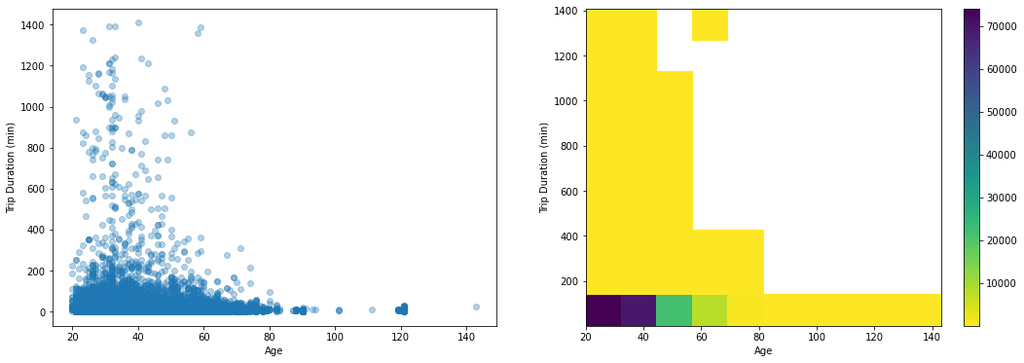

```python
# plot relation between Age & trip duration

plt.figure(figsize = [18, 6])

# PLOT ON LEFT
plt.subplot(1, 2, 1)
sb.regplot(data = bike_shares_df, x = 'age', y = 'duration_min', scatter_kws={'alpha':1/3}, fit_reg=False)
plt.xlabel('Age')
plt.ylabel('Trip Duration (min)');

# PLOT ON RIGHT
plt.subplot(1, 2, 2)
plt.hist2d(data = bike_shares_df, x = 'age', y = 'duration_min', cmin=0.5, cmap='viridis_r')
plt.colorbar()
plt.xlabel('Age')
plt.ylabel('Trip Duration (min)');
```

##### The distribution shows more density in the large trip duration in the `age` region between 20 to 40 years & more density in low duration trips in the 20 to 30 years `age` region.

1. Hour of day

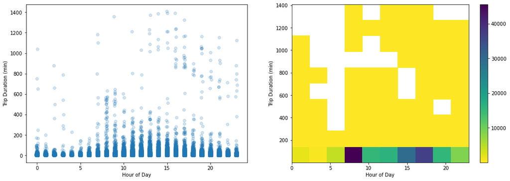

```python
# plot relation between Hour of day & trip duration

plt.figure(figsize = [18, 6])

# PLOT ON LEFT
plt.subplot(1, 2, 1)
sb.regplot(data = bike_shares_df, x = 'start_hour_of_day', y = 'duration_min', x_jitter=0.1, scatter_kws={'alpha':1/5}, fit_reg=False)
plt.xlabel('Hour of Day')
plt.ylabel('Trip Duration (min)');

# PLOT ON RIGHT
plt.subplot(1, 2, 2)
plt.hist2d(data = bike_shares_df, x = 'start_hour_of_day', y = 'duration_min', cmin=0.5, cmap='viridis_r')
plt.colorbar()
plt.xlabel('Hour of Day')
plt.ylabel('Trip Duration (min)');
```

1. Day of week

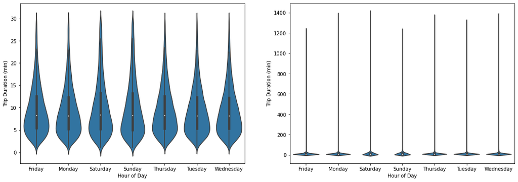

```python
# plot relation between Day of week & trip duration

data = bike_shares_df[bike_shares_df["duration_min"] < 30]

base_color = sb.color_palette()[0]

plt.figure(figsize = [18, 6])

# PLOT ON LEFT
plt.subplot(1, 2, 1)

sb.violinplot(data=data, y='duration_min', x='start_day_of_week', color=base_color, innner=None);

plt.xlabel('Hour of Day')
plt.ylabel('Trip Duration (min)');

# PLOT ON RIGHT
plt.subplot(1, 2, 2)

sb.violinplot(data=bike_shares_df, y='duration_min', x='start_day_of_week', color=base_color, innner=None);

plt.xlabel('Hour of Day')
plt.ylabel('Trip Duration (min)');
```

1. Relation between Day of week & Hour of day

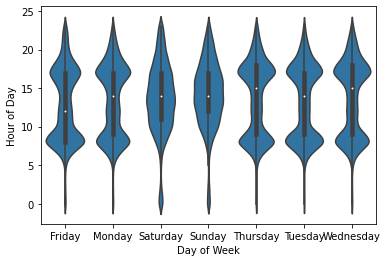

```python
# plot relation between Day of week & Hour of day

base_color = sb.color_palette()[0]

sb.violinplot(data=bike_shares_df, y='start_hour_of_day', x='start_day_of_week', color=base_color, innner=None);

plt.xlabel('Day of Week');
plt.ylabel('Hour of Day');
```

1. Relation between Age & Hour of day, 6. Age & Day of week

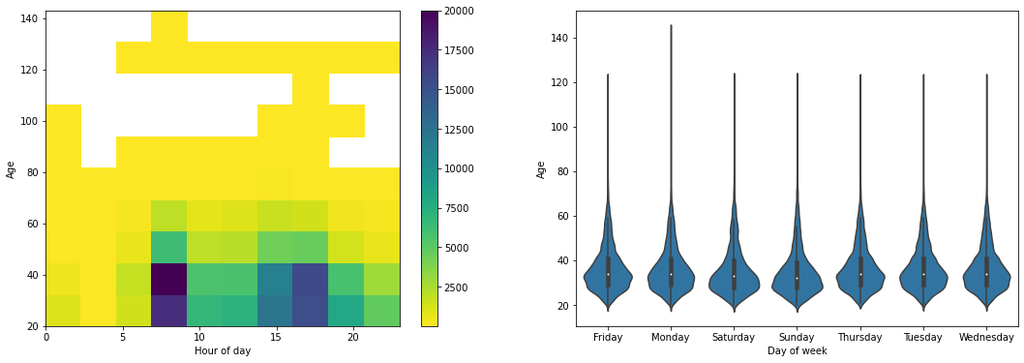

```python
# plot relation between Age & Hour of day

plt.figure(figsize = [18, 6])

plt.subplot(1, 2, 1)
plt.hist2d(data = bike_shares_df, x = 'start_hour_of_day', y = 'age', cmin=0.5, cmap='viridis_r')
plt.colorbar()

plt.xlabel('Hour of day')
plt.ylabel('Age');

# plot relation between Age & Day of Week

plt.subplot(1, 2, 2)
sb.violinplot(data=bike_shares_df, x='start_day_of_week', y='age', color=base_color, innner=None);
plt.xlabel('Day of week')
plt.ylabel('Age');
```

##### The Hour of day with age distribution shows more density between hour 8 - 9 & between hour 17 - 18 for age between 20 & 50 years.

1. Relation between Gender & Hour of day, 7. Gender & Day of week

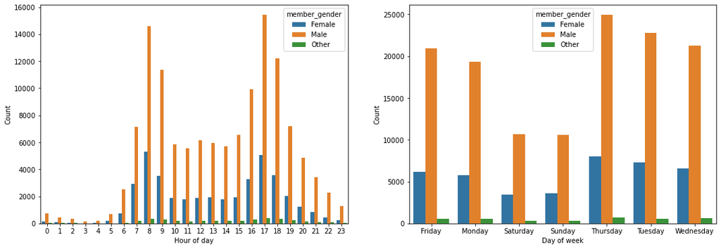

```python
# plot relation between Gender & Hour of day

plt.figure(figsize = [18, 6])

plt.subplot(1, 2, 1)
sb.countplot(data = bike_shares_df, x = 'start_hour_of_day', hue = 'member_gender')
plt.xlabel('Hour of day')
plt.ylabel('Count');

# plot relation Gender & Day of week

plt.subplot(1, 2, 2)
sb.countplot(data = bike_shares_df, x = 'start_day_of_week', hue = 'member_gender')
plt.xlabel('Day of week')
plt.ylabel('Count');
```

##### The Hour of day with gender distribution don't show change in the shape for male & female as both shows bimodal distribution with two peaks at 8 & 17 hours.

##### The day of week with gender distribution shows less density on weekend days for both males & females.

1. Relation between Age & Gender

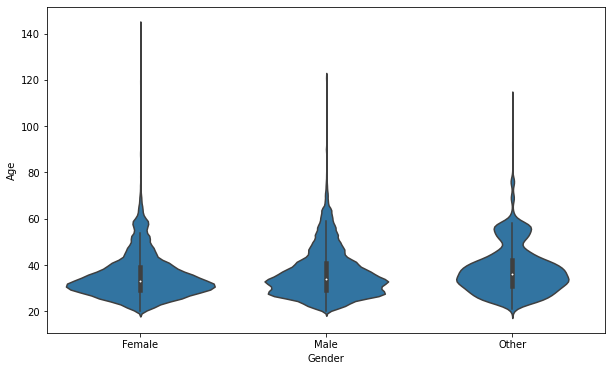

```python
# plot relation between Age & Gender

plt.figure(figsize = [10, 6])
sb.violinplot(data=bike_shares_df, x='member_gender', y='age', color=base_color, innner=None);
plt.xlabel('Gender')
plt.ylabel('Age');
```

### Talk about some of the relationships you observed in this part of the investigation. How did the feature(s) of interest vary with other features in the dataset?

- The main intresting fact I've observed that day of week clearly affects other features like trip duration and hour of the day.

### Did you observe any interesting relationships between the other features (not the main feature(s) of interest)?

- Yes, the Age feature showed more density between between 20 & 50 years in the peak hours than other ages.
- Also age distribution showed different densities for different genders

## Multivariate Exploration

In this section, I'm intrested in investigating the features affecting trip duration together so I'll study the relation between it and:

1. day of week & gender.
2. hour of day & gender
3. day of week & user type
4. hour of day & user type

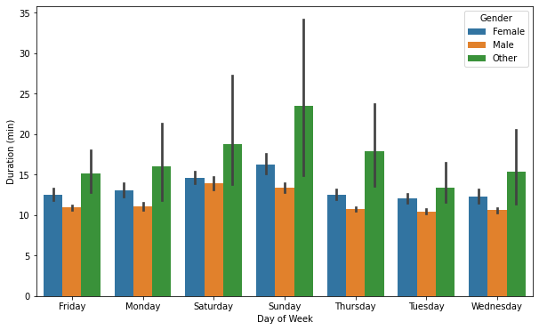

```python
# plot relation between trip duration & day of week & gender
plt.figure(figsize = [10, 6])

sb.barplot(data = bike_shares_df, x = 'start_day_of_week', y = 'duration_min', hue = 'member_gender');

plt.xlabel('Day of Week')
plt.ylabel('Duration (min)')

plt.legend(title="Gender");
```

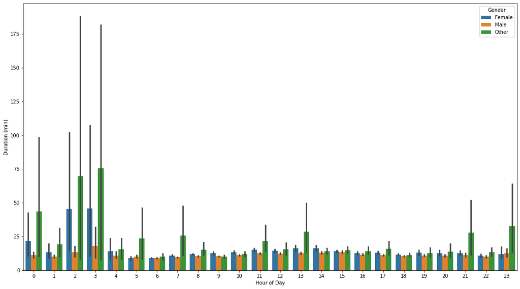

```python
# plot relation between trip duration & hour of day & gender

plt.figure(figsize = [18, 10])

sb.barplot(data = bike_shares_df, x = 'start_hour_of_day', y = 'duration_min', hue = 'member_gender');

plt.xlabel('Hour of Day')
plt.ylabel('Duration (min)')

plt.legend(title="Gender");
```

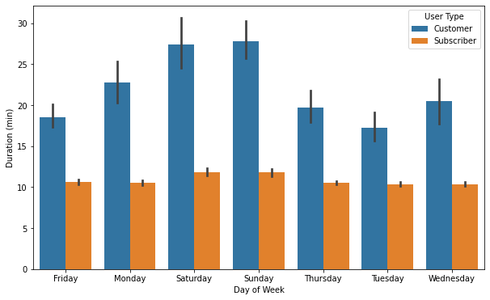

```python
# plot relation between trip duration & day of week & user type

plt.figure(figsize = [10, 6])

sb.barplot(data = bike_shares_df, x = 'start_day_of_week', y = 'duration_min', hue = 'user_type');

plt.xlabel('Day of Week')
plt.ylabel('Duration (min)')

plt.legend(title="User Type");
```

#### We can see from this chart that customers has larger trip durations than subscribers & they also make larger trips on weekends than work days.

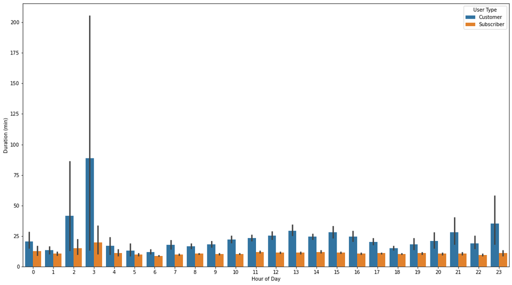

```python
# plot relation between trip duration & hour of the day & user type

plt.figure(figsize = [18, 10])

sb.barplot(data = bike_shares_df, x = 'start_hour_of_day', y = 'duration_min', hue = 'user_type');

plt.xlabel('Hour of Day')
plt.ylabel('Duration (min)')

plt.legend(title="User Type");
```

### Were there any interesting or surprising interactions between features?

From all relations we studied we can conclude some interesting insights:

- Women have larger trip than men.
- Customers have larger trips than subscribers & they ride for more time on holidays.
- People in general ride more on working days & mostly on the start, end of day